# Bellabeat Report

Fikayo

2022-05-27

# Summary

Bellabeat is a high-tech manufacturer of health-focused products for women. Bellabeat is a successful small company, but they have the potential to become a larger player in the global smart device market. Urška Sršen, cofounder and Chief Creative Officer of Bellabeat, believes that analyzing smart device fitness data could help unlock new growth opportunities for the company.

# Phase 1: ASK

## **Objectives**

### *Identify business task*

- Business questions to be answered are:
  - What are some trends in smart device usage?
  - How could these trends apply to Bellabeat customers?
  - How could these trends help influence Bellabeat marketing strategy?
- These questions will be used to assess and identify potential opportunities for growth for the company. Likewise, recommendations for the Bellabeat marketing strategy improvement based on trends in smart device usage should be determined. Based on these factors, the key business task is, therefore:
- To identify trends in how consumers use non-Bellabeat smart devices to apply insights into Bellabeat’s marketing strategy.

### *Consider key stakeholders*

- Urška Sršen - Bellabeat co-founder and Chief Creative Officer
- Sando Mur - Bellabeat co-founder and a key member of the Bellabeat executive team
- Bellabeat Marketing Analytics team

# Phase 2: PREPARE

## **Objectives**

### *What dataset is to be used*

For this project, I will use FitBit Fitness Tracker data collected from [Kaggle.com](https://www.kaggle.com/datasets/arashnic/fitbit).

### *Determine data format*

The dataset downloaded from Kaggle is stored in long format as opposed to wide format.

### *Determine the credibility of data*

The dataset for analysis is stored in CSV format with hundreds of rows in 18 CSV files.

# Phase 3: PROCESS

## Objectives

### *Tools used*

For this project, the analysis will be conducted in R due to its ease in handling big data, its accessibility, and its ability to create data visualization and to easily share my results with stakeholders.

### *Import datasets*

Due to the small sample size, we won’t consider for this analysis the Weight (8 Users) and heart rate (7 users) tables, but will rather focus on using only the daily activity file and the sleep file. To preview our dataset, selected data frames are created and the summary of each column is checked. To begin, we have to import the necessary libraries and install the necessary packages for the analysis.

```r
install.packages('tidyverse')
install.packages('here')
install.packages('janitor')
install.packages('lubridate')
library(tidyverse)
```

```r
library(dplyr)
library(ggplot2)
library(tidyr)
library(lubridate)
library(here)
library(skimr)
library(janitor)
library(ggrepel)
library(ggpubr)
```

The datasets that are gonna be used for analysis are imported. Then they are stored in separate data frames called daily_activity and sleep_day respectively.

```r
daily_activity <- read.csv("dailyActivity_merged.csv")
sleep_day <- read.csv("sleepDay_merged.csv")
```

```r
head(daily_activity)
```

|  | Id | ActivityDate | TotalSteps | TotalDistance | TrackerDistance | LoggedActivitiesDistance | VeryActiveDistance | ModeratelyActiveDistance | LightActiveDistance | SedentaryActiveDistance | VeryActiveMinutes | FairlyActiveMinutes | LightlyActiveMinutes | SedentaryMinutes | Calories |
| --- | --- | --- | --- | --- | --- | --- | --- | --- | --- | --- | --- | --- | --- | --- | --- |
| 1 | 1503960366 | 4/12/2016 | 13162 | 8.50 | 8.50 | 0 | 1.88 | 0.55 | 6.06 | 0 | 25 | 13 | 328 | 728 | 1985 |
| 2 | 1503960366 | 4/13/2016 | 10735 | 6.97 | 6.97 | 0 | 1.57 | 0.69 | 4.71 | 0 | 21 | 19 | 217 | 776 | 1797 |
| 3 | 1503960366 | 4/14/2016 | 10460 | 6.74 | 6.74 | 0 | 2.44 | 0.40 | 3.91 | 0 | 30 | 11 | 181 | 1218 | 1776 |
| 4 | 1503960366 | 4/15/2016 | 9762 | 6.28 | 6.28 | 0 | 2.14 | 1.26 | 2.83 | 0 | 29 | 34 | 209 | 726 | 1745 |
| 5 | 1503960366 | 4/16/2016 | 12669 | 8.16 | 8.16 | 0 | 2.71 | 0.41 | 5.04 | 0 | 36 | 10 | 221 | 773 | 1863 |
| 6 | 1503960366 | 4/17/2016 | 9705 | 6.48 | 6.48 | 0 | 3.19 | 0.78 | 2.51 | 0 | 38 | 20 | 164 | 539 | 1728 |

```r
str(daily_activity)
```

```
## 'data.frame':    940 obs. of  15 variables:
##  $ Id                      : num  1.5e+09 1.5e+09 1.5e+09 1.5e+09 1.5e+09 ...
##  $ ActivityDate            : chr  "4/12/2016" "4/13/2016" "4/14/2016" "4/15/2016" ...
##  $ TotalSteps              : int  13162 10735 10460 9762 12669 9705 13019 15506 10544 9819 ...
##  $ TotalDistance           : num  8.5 6.97 6.74 6.28 8.16 ...
##  $ TrackerDistance         : num  8.5 6.97 6.74 6.28 8.16 ...
##  $ LoggedActivitiesDistance: num  0 0 0 0 0 0 0 0 0 0 ...
##  $ VeryActiveDistance      : num  1.88 1.57 2.44 2.14 2.71 ...
##  $ ModeratelyActiveDistance: num  0.55 0.69 0.4 1.26 0.41 ...
##  $ LightActiveDistance     : num  6.06 4.71 3.91 2.83 5.04 ...
##  $ SedentaryActiveDistance : num  0 0 0 0 0 0 0 0 0 0 ...
##  $ VeryActiveMinutes       : int  25 21 30 29 36 38 42 50 28 19 ...
##  $ FairlyActiveMinutes     : int  13 19 11 34 10 20 16 31 12 8 ...
##  $ LightlyActiveMinutes    : int  328 217 181 209 221 164 233 264 205 211 ...
##  $ SedentaryMinutes        : int  728 776 1218 726 773 539 1149 775 818 838 ...
##  $ Calories                : int  1985 1797 1776 1745 1863 1728 1921 2035 1786 1775 ...
```

```r
head(sleep_day)
```

|  | Id | SleepDay | TotalSleepRecords | TotalMinutesAsleep | TotalTimeInBed |
| --- | --- | --- | --- | --- | --- |
| 1 | 1503960366 | 4/12/2016 12:00:00 AM | 1 | 327 | 346 |
| 2 | 1503960366 | 4/13/2016 12:00:00 AM | 2 | 384 | 407 |
| 3 | 1503960366 | 4/15/2016 12:00:00 AM | 1 | 412 | 442 |
| 4 | 1503960366 | 4/16/2016 12:00:00 AM | 2 | 340 | 367 |
| 5 | 1503960366 | 4/17/2016 12:00:00 AM | 1 | 700 | 712 |
| 6 | 1503960366 | 4/19/2016 12:00:00 AM | 1 | 304 | 320 |

```r
str(sleep_day)
```

```
## 'data.frame':    413 obs. of  5 variables:
##  $ Id                : num  1.5e+09 1.5e+09 1.5e+09 1.5e+09 1.5e+09 ...
##  $ SleepDay          : chr  "4/12/2016 12:00:00 AM" "4/13/2016 12:00:00 AM" "4/15/2016 12:00:00 AM" "4/16/2016 12:00:00 AM" ...
##  $ TotalSleepRecords : int  1 2 1 2 1 1 1 1 1 1 ...
##  $ TotalMinutesAsleep: int  327 384 412 340 700 304 360 325 361 430 ...
##  $ TotalTimeInBed    : int  346 407 442 367 712 320 377 364 384 449 ...
```

### *Cleaning Process*

To begin the cleaning process, both data frames are searched for duplicates.

##### Removing Duplicates

```r
sum(duplicated(daily_activity))
```

```
## [1] 0
```

```r
sum(duplicated(sleep_day))
```

```
## [1] 3
```

The result of the search shows that the data frame containing sleep data has some duplicates, so we remove the empty rows to clean the data.

```r
sleep_day <- sleep_day %>%
  distinct() %>%
  drop_na()
```

Then we check again to confirm that the empty rows have been dropped.

```r
sum(duplicated(sleep_day))
```

```
## [1] 0
```

##### Renaming Columns

To help keep formatting clean, and to ensure our column names align with naming conventions, we’ll rename all columns to lowercase format.

[output not shown]

[output cut: 930 more lines]

[output not shown]

[output cut: 400 more lines]

##### Date Formatting

We have to format our date columns into the proper format, because R automatically imports and converts date values into strings. So we have to then convert said columns back to the proper format.

```r
# activity
daily_activity <- daily_activity %>%
  rename(date = activitydate) %>%
  mutate(date = as_date(date, format = "%m/%d/%Y"))
```

```r
# sleep
sleep_day <- sleep_day %>%
  rename(date = sleepday) %>%
  mutate(date = as_date(date,format ="%m/%d/%Y %I:%M:%S %p" , tz=Sys.timezone()))
```

We then check to confirm that the date column has been converted.

```r
head(daily_activity)
```

|  | id | date | totalsteps | totaldistance | trackerdistance | loggedactivitiesdistance | veryactivedistance | moderatelyactivedistance | lightactivedistance | sedentaryactivedistance | veryactiveminutes | fairlyactiveminutes | lightlyactiveminutes | sedentaryminutes | calories |
| --- | --- | --- | --- | --- | --- | --- | --- | --- | --- | --- | --- | --- | --- | --- | --- |
| 1 | 1503960366 | 2016-04-12 | 13162 | 8.50 | 8.50 | 0 | 1.88 | 0.55 | 6.06 | 0 | 25 | 13 | 328 | 728 | 1985 |
| 2 | 1503960366 | 2016-04-13 | 10735 | 6.97 | 6.97 | 0 | 1.57 | 0.69 | 4.71 | 0 | 21 | 19 | 217 | 776 | 1797 |
| 3 | 1503960366 | 2016-04-14 | 10460 | 6.74 | 6.74 | 0 | 2.44 | 0.40 | 3.91 | 0 | 30 | 11 | 181 | 1218 | 1776 |
| 4 | 1503960366 | 2016-04-15 | 9762 | 6.28 | 6.28 | 0 | 2.14 | 1.26 | 2.83 | 0 | 29 | 34 | 209 | 726 | 1745 |
| 5 | 1503960366 | 2016-04-16 | 12669 | 8.16 | 8.16 | 0 | 2.71 | 0.41 | 5.04 | 0 | 36 | 10 | 221 | 773 | 1863 |
| 6 | 1503960366 | 2016-04-17 | 9705 | 6.48 | 6.48 | 0 | 3.19 | 0.78 | 2.51 | 0 | 38 | 20 | 164 | 539 | 1728 |

```r
str(daily_activity)
```

```
## 'data.frame':    940 obs. of  15 variables:
##  $ id                      : num  1.5e+09 1.5e+09 1.5e+09 1.5e+09 1.5e+09 ...
##  $ date                    : Date, format: "2016-04-12" "2016-04-13" ...
##  $ totalsteps              : int  13162 10735 10460 9762 12669 9705 13019 15506 10544 9819 ...
##  $ totaldistance           : num  8.5 6.97 6.74 6.28 8.16 ...
##  $ trackerdistance         : num  8.5 6.97 6.74 6.28 8.16 ...
##  $ loggedactivitiesdistance: num  0 0 0 0 0 0 0 0 0 0 ...
##  $ veryactivedistance      : num  1.88 1.57 2.44 2.14 2.71 ...
##  $ moderatelyactivedistance: num  0.55 0.69 0.4 1.26 0.41 ...
##  $ lightactivedistance     : num  6.06 4.71 3.91 2.83 5.04 ...
##  $ sedentaryactivedistance : num  0 0 0 0 0 0 0 0 0 0 ...
##  $ veryactiveminutes       : int  25 21 30 29 36 38 42 50 28 19 ...
##  $ fairlyactiveminutes     : int  13 19 11 34 10 20 16 31 12 8 ...
##  $ lightlyactiveminutes    : int  328 217 181 209 221 164 233 264 205 211 ...
##  $ sedentaryminutes        : int  728 776 1218 726 773 539 1149 775 818 838 ...
##  $ calories                : int  1985 1797 1776 1745 1863 1728 1921 2035 1786 1775 ...
```

```r
head(sleep_day)
```

|  | id | date | totalsleeprecords | totalminutesasleep | totaltimeinbed |
| --- | --- | --- | --- | --- | --- |
| 1 | 1503960366 | 2016-04-12 | 1 | 327 | 346 |
| 2 | 1503960366 | 2016-04-13 | 2 | 384 | 407 |
| 3 | 1503960366 | 2016-04-15 | 1 | 412 | 442 |
| 4 | 1503960366 | 2016-04-16 | 2 | 340 | 367 |
| 5 | 1503960366 | 2016-04-17 | 1 | 700 | 712 |
| 6 | 1503960366 | 2016-04-19 | 1 | 304 | 320 |

```r
str(sleep_day)
```

```
## 'data.frame':    410 obs. of  5 variables:
##  $ id                : num  1.5e+09 1.5e+09 1.5e+09 1.5e+09 1.5e+09 ...
##  $ date              : Date, format: "2016-04-12" "2016-04-13" ...
##  $ totalsleeprecords : int  1 2 1 2 1 1 1 1 1 1 ...
##  $ totalminutesasleep: int  327 384 412 340 700 304 360 325 361 430 ...
##  $ totaltimeinbed    : int  346 407 442 367 712 320 377 364 384 449 ...
```

##### Verifying Dataset

Now that our data has been properly formatted and cleaned, we’ll need to confirm the number of users in each data frame so that we can determine the usability of our data.

```r
n_distinct(daily_activity$id)
```

```
## [1] 33
```

```r
n_distinct(sleep_day$id)
```

```
## [1] 24
```

```r
daily_activity_sleep <- merge(daily_activity, sleep_day, by.x = "id", by.y = "id")
glimpse(daily_activity_sleep)
```

```
## Rows: 12,348
## Columns: 19
## $ id                       <dbl> 1503960366, 1503960366, 1503960366, 150396036…
## $ date.x                   <date> 2016-05-07, 2016-05-07, 2016-05-07, 2016-05-…
## $ totalsteps               <int> 11992, 11992, 11992, 11992, 11992, 11992, 119…
## $ totaldistance            <dbl> 7.71, 7.71, 7.71, 7.71, 7.71, 7.71, 7.71, 7.7…
## $ trackerdistance          <dbl> 7.71, 7.71, 7.71, 7.71, 7.71, 7.71, 7.71, 7.7…
## $ loggedactivitiesdistance <dbl> 0, 0, 0, 0, 0, 0, 0, 0, 0, 0, 0, 0, 0, 0, 0, …
## $ veryactivedistance       <dbl> 2.46, 2.46, 2.46, 2.46, 2.46, 2.46, 2.46, 2.4…
## $ moderatelyactivedistance <dbl> 2.12, 2.12, 2.12, 2.12, 2.12, 2.12, 2.12, 2.1…
## $ lightactivedistance      <dbl> 3.13, 3.13, 3.13, 3.13, 3.13, 3.13, 3.13, 3.1…
## $ sedentaryactivedistance  <dbl> 0, 0, 0, 0, 0, 0, 0, 0, 0, 0, 0, 0, 0, 0, 0, …
## $ veryactiveminutes        <int> 37, 37, 37, 37, 37, 37, 37, 37, 37, 37, 37, 3…
## $ fairlyactiveminutes      <int> 46, 46, 46, 46, 46, 46, 46, 46, 46, 46, 46, 4…
## $ lightlyactiveminutes     <int> 175, 175, 175, 175, 175, 175, 175, 175, 175, …
## $ sedentaryminutes         <int> 833, 833, 833, 833, 833, 833, 833, 833, 833, …
## $ calories                 <int> 1821, 1821, 1821, 1821, 1821, 1821, 1821, 182…
## $ date.y                   <date> 2016-04-12, 2016-04-13, 2016-04-15, 2016-04-…
## $ totalsleeprecords        <int> 1, 2, 1, 2, 1, 1, 1, 1, 1, 1, 1, 1, 1, 1, 1, …
## $ totalminutesasleep       <int> 327, 384, 412, 340, 700, 304, 360, 325, 361, …
## $ totaltimeinbed           <int> 346, 407, 442, 367, 712, 320, 377, 364, 384, …
```

```r
head(daily_activity_sleep)
```

|  | id | date.x | totalsteps | totaldistance | trackerdistance | loggedactivitiesdistance | veryactivedistance | moderatelyactivedistance | lightactivedistance | sedentaryactivedistance | veryactiveminutes | fairlyactiveminutes | lightlyactiveminutes | sedentaryminutes | calories | date.y | totalsleeprecords | totalminutesasleep | totaltimeinbed |
| --- | --- | --- | --- | --- | --- | --- | --- | --- | --- | --- | --- | --- | --- | --- | --- | --- | --- | --- | --- |
| 1 | 1503960366 | 2016-05-07 | 11992 | 7.71 | 7.71 | 0 | 2.46 | 2.12 | 3.13 | 0 | 37 | 46 | 175 | 833 | 1821 | 2016-04-12 | 1 | 327 | 346 |
| 2 | 1503960366 | 2016-05-07 | 11992 | 7.71 | 7.71 | 0 | 2.46 | 2.12 | 3.13 | 0 | 37 | 46 | 175 | 833 | 1821 | 2016-04-13 | 2 | 384 | 407 |
| 3 | 1503960366 | 2016-05-07 | 11992 | 7.71 | 7.71 | 0 | 2.46 | 2.12 | 3.13 | 0 | 37 | 46 | 175 | 833 | 1821 | 2016-04-15 | 1 | 412 | 442 |
| 4 | 1503960366 | 2016-05-07 | 11992 | 7.71 | 7.71 | 0 | 2.46 | 2.12 | 3.13 | 0 | 37 | 46 | 175 | 833 | 1821 | 2016-04-16 | 2 | 340 | 367 |
| 5 | 1503960366 | 2016-05-07 | 11992 | 7.71 | 7.71 | 0 | 2.46 | 2.12 | 3.13 | 0 | 37 | 46 | 175 | 833 | 1821 | 2016-04-17 | 1 | 700 | 712 |
| 6 | 1503960366 | 2016-05-07 | 11992 | 7.71 | 7.71 | 0 | 2.46 | 2.12 | 3.13 | 0 | 37 | 46 | 175 | 833 | 1821 | 2016-04-19 | 1 | 304 | 320 |

Now that our data has been verified and formatted, we can begin to work with it.

# Phase 5: Analyze

First, we want to get a summary of some of the important values in each dataset before merging.

### *Summarizing Data*

```r
# Activity
daily_activity %>%
  select(totalsteps,
         totaldistance,
         sedentaryminutes) %>%
    summary()
```

```
##    totalsteps    totaldistance    sedentaryminutes
##  Min.   :    0   Min.   : 0.000   Min.   :   0.0
##  1st Qu.: 3790   1st Qu.: 2.620   1st Qu.: 729.8
##  Median : 7406   Median : 5.245   Median :1057.5
##  Mean   : 7638   Mean   : 5.490   Mean   : 991.2
##  3rd Qu.:10727   3rd Qu.: 7.713   3rd Qu.:1229.5
##  Max.   :36019   Max.   :28.030   Max.   :1440.0
```

```r
# Sleep
sleep_day %>%
  select(totalsleeprecords,
         totalminutesasleep,
         totaltimeinbed) %>%
  summary()
```

```
##  totalsleeprecords totalminutesasleep totaltimeinbed
##  Min.   :1.00      Min.   : 58.0      Min.   : 61.0
##  1st Qu.:1.00      1st Qu.:361.0      1st Qu.:403.8
##  Median :1.00      Median :432.5      Median :463.0
##  Mean   :1.12      Mean   :419.2      Mean   :458.5
##  3rd Qu.:1.00      3rd Qu.:490.0      3rd Qu.:526.0
##  Max.   :3.00      Max.   :796.0      Max.   :961.0
```

```r
daily_average <- daily_activity_sleep %>%
  group_by(id) %>%
  summarise (mean_daily_steps = mean(totalsteps), mean_daily_calories = mean(calories), mean_daily_sleep = mean(totalminutesasleep))

head(daily_average)
```

| id | mean_daily_steps | mean_daily_calories | mean_daily_sleep |
| --- | --- | --- | --- |
| 1503960366 | 12116.742 | 1816.419 | 360.2800 |
| 1644430081 | 7282.967 | 2811.300 | 294.0000 |
| 1844505072 | 2580.065 | 1573.484 | 652.0000 |
| 1927972279 | 916.129 | 2172.806 | 417.0000 |
| 2026352035 | 5566.871 | 1540.645 | 506.1786 |
| 2320127002 | 4716.871 | 1724.161 | 61.0000 |

```r
user_type <- daily_average %>%
  mutate(user_type = case_when(
    mean_daily_steps < 5000 ~ "sedentary",
    mean_daily_steps >= 5000 & mean_daily_steps < 7499 ~ "lightly active",
    mean_daily_steps >= 7500 & mean_daily_steps < 9999 ~ "fairly active",
    mean_daily_steps >= 10000 ~ "very active"
  ))

head(user_type)
```

| id | mean_daily_steps | mean_daily_calories | mean_daily_sleep | user_type |
| --- | --- | --- | --- | --- |
| 1503960366 | 12116.742 | 1816.419 | 360.2800 | very active |
| 1644430081 | 7282.967 | 2811.300 | 294.0000 | lightly active |
| 1844505072 | 2580.065 | 1573.484 | 652.0000 | sedentary |
| 1927972279 | 916.129 | 2172.806 | 417.0000 | sedentary |
| 2026352035 | 5566.871 | 1540.645 | 506.1786 | lightly active |
| 2320127002 | 4716.871 | 1724.161 | 61.0000 | sedentary |

We can further determine the percentage of users based on their activity level.

```r
user_type_percent <- user_type %>%
  group_by(user_type) %>%
  summarise(total = n()) %>%
  mutate(totals = sum(total)) %>%
  group_by(user_type) %>%
  summarise(total_percent = total / totals) %>%
  mutate(labels = scales::percent(total_percent))

user_type_percent$user_type <- factor(user_type_percent$user_type , levels = c("very active", "fairly active", "lightly active", "sedentary"))


head(user_type_percent)
```

| user_type | total_percent | labels |
| --- | --- | --- |
| fairly active | 0.3333333 | 33.3% |
| lightly active | 0.1666667 | 16.7% |
| sedentary | 0.2916667 | 29.2% |
| very active | 0.2083333 | 20.8% |

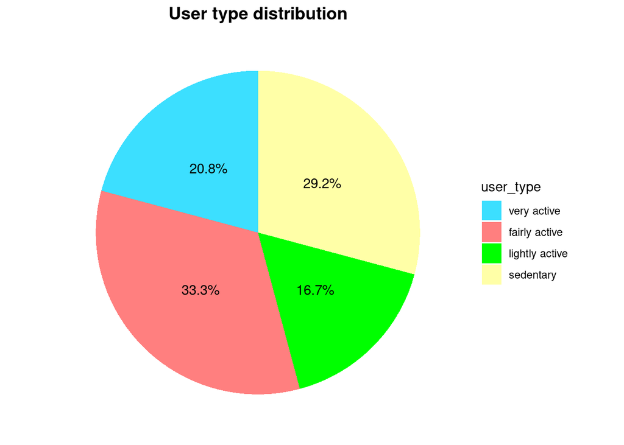

```r
user_type_percent %>%
  ggplot(aes(x="",y=total_percent, fill=user_type)) +
  geom_bar(stat = "identity", width = 1)+
  coord_polar("y", start=0)+
  theme_minimal()+
  theme(axis.title.x= element_blank(),
        axis.title.y = element_blank(),
        panel.border = element_blank(),
        panel.grid = element_blank(),
        axis.ticks = element_blank(),
        axis.text.x = element_blank(),
        plot.title = element_text(hjust = 0.5, size=14, face = "bold")) +
  scale_fill_manual(values = c("#3CDFFF","#FF7F7F", "#00FF00", "#ffffa7")) +
  geom_text(aes(label = labels),
            position = position_stack(vjust = 0.5))+
  labs(title="User type distribution")
```

From our visualization, we can see that a sizable number of users are fairly active, lightly active and sedentary. Which accounts for the huge difference between the mean steps taken and the maximum.

### *Visualization*

To help analyze our data, we’ll go ahead and visualize our data.

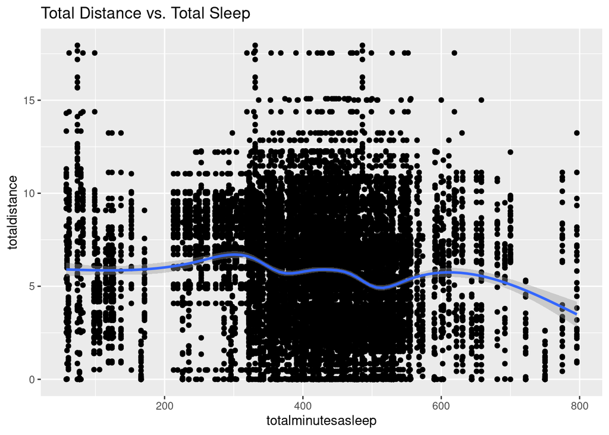

```r
ggplot(data=daily_activity_sleep, aes(x=totalminutesasleep, y=totaldistance)) +
  geom_point() + geom_smooth() + labs(title="Total Distance vs. Total Sleep")
```

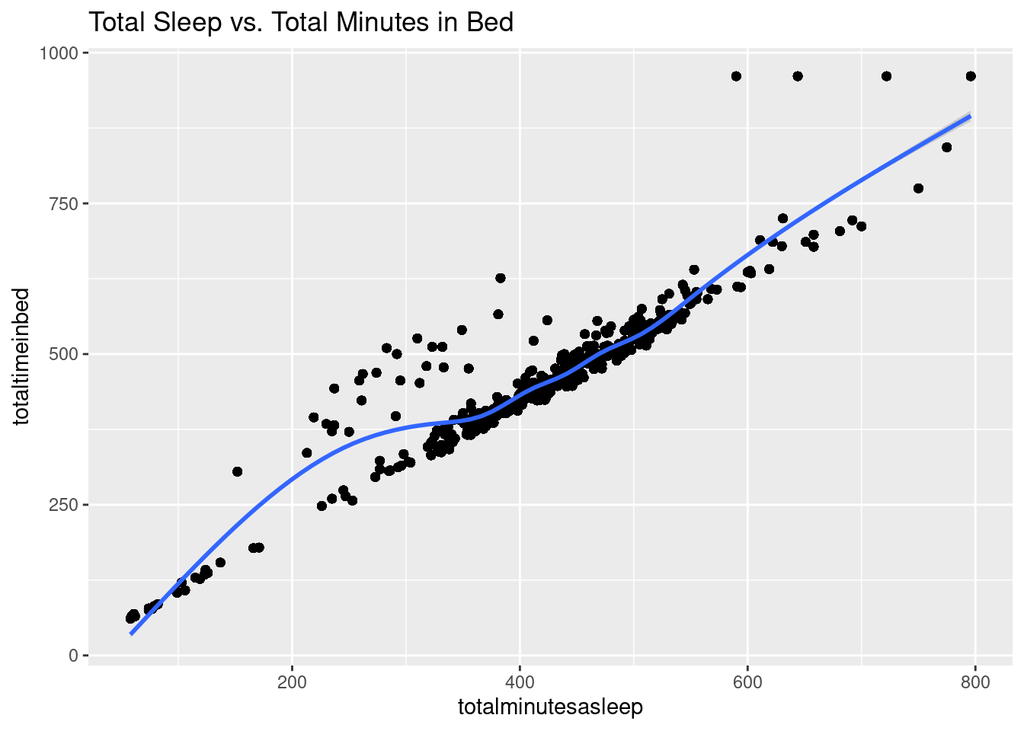

```r
ggplot(data=daily_activity_sleep, aes(x=totalminutesasleep, y=totaltimeinbed)) +
  geom_point() + geom_smooth() + labs(title="Total Sleep vs. Total Minutes in Bed")
```

Further analysis shows that the more time spent in bed, the more sleep users were able to get. A very useful insight, which can help effect recommendations.

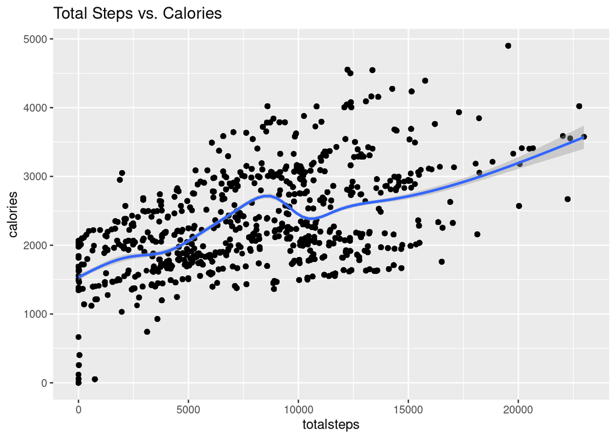

```r
ggplot(data=daily_activity_sleep, aes(x=totalsteps, y=calories)) +
  geom_point() + geom_smooth() + labs(title="Total Steps vs. Calories")
```